```
                              #'#Group 2 Team Members

                                  * Brian Bennett
                                 * Gayathri Sanjeev
                                    * Lok Ngan
                               * Michael Chechenitsky
```

# Introduction

In this project, we aim to explore the transaction data of a bakery, located in Edinburgh, and study the purchasing behavior of consumers of bakery as related to time and weather.

In particular, we are looking to accomplish the following:

- Determine what are the factors that drive businesses to a bakery:
  - Time of day
  - Day of week
- Develop understanding on the purchasing behaviors of bakery customers:
  - Popular items
  - Items that are frequently bought together
- Does weather play a factor on bakery transactions?

The bakery dataset used for this project is obtained from Kaggle:

https://www.kaggle.com/sulmansarwar/transactions-from-a-bakery

Weather data used for this project is obtained from the School of Geosciences from the University of Edinburgh:

https://www.geos.ed.ac.uk/~weather/jcmb_ws/

## Bakery Data

#### Load and clean bakery data

The bakery data from Kaggle is pretty clean and only a small amount of data cleaning is needed.

```r
# dataframe of TimeOfDay

GetBakeryData <- function(){
  df <- read.csv('C:/Users/gagd2/Desktop/Syracuse/IST_687/Assignments/Project/BreadBasket_DMS.csv', header=TRUE, stringsAsFactors = FALSE)

  # Add hour interval to data
  df$Hour <- as.numeric(lapply(df$Time, function(x){substring(x,1,2)}))

  # Format date as date
  df$Date <- as.Date(df$Date,"%Y-%m-%d")

  # Remove NONE
  df <- df[!df$Item %in% c('NONE','Adjustment'),]
  df <- df[c(1,5,3,4)]

  return(df)
}

dfBakery <- GetBakeryData()

dfBakery.Day <- dfBakery %>%
  group_by(Date) %>%
  summarise(count = length(Item))
```

The data is loaded into a dataframe, named *dfBakery*, and the following operations were done to the dataframe:  
* Extracted the hour from time  
* Reformatted the date as date  
* Deleted items that are not useful to our analysis (‘NONE’ and ‘adjustment’)  
* Removed unnecessary columns

A separate dataframe, named *dfBakery.Day*, by aggregating the data by day is also generated.

#### Analyze Bakery Data

An initial review of the bakery data was done by gaining some understanding on how day and time drive businesses to the bakery.

##### Bakery transactions by day

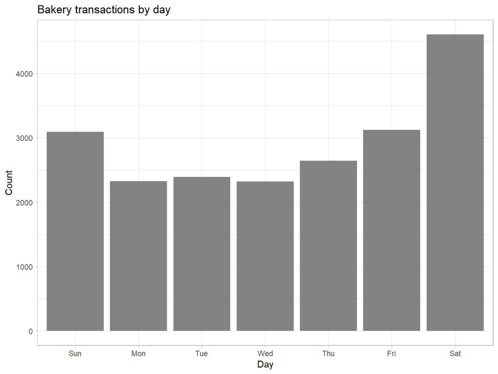

```r
b1 <- dfBakery %>%
  mutate(Weekday = wday(Date,label=TRUE)) %>%
  group_by(Weekday) %>%
  summarise(Count = length(Item)) %>%
  ggplot(aes(x=Weekday,y=Count)) +
  theme_light() +
  geom_bar(stat='identity',alpha=0.75) +
  labs(title=paste('Bakery transactions by day'),
     x = 'Day',
     y = 'Count')
b1
```

##### Bakery transactions by hour

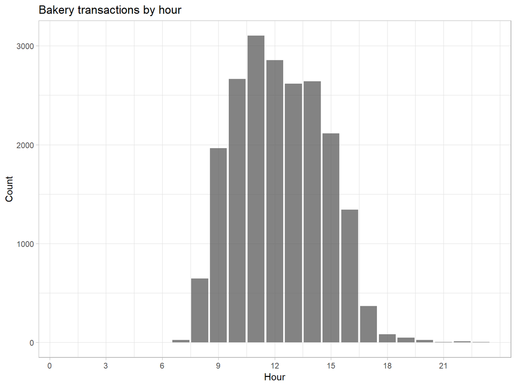

```r
b2 <- dfBakery %>%
  group_by(Hour) %>%
  summarise(Count = length(Item)) %>%
  ggplot(aes(x=Hour,y=Count)) +
  theme_light() +
  geom_bar(stat='identity',alpha=0.75) +
  scale_x_continuous(breaks = seq(0,23, by = 3)) +
  labs(title=paste('Bakery transactions by hour'),
     x = 'Hour',
     y = 'Count')
b2
```

And, Lunch hours (11am and 12pm) are the most popular times to go to the bakery.

#### Purchasing behaviors

Followed by reviewing data by day and time, the purchasing behaviors of the customers were analyzed.

##### Popular items

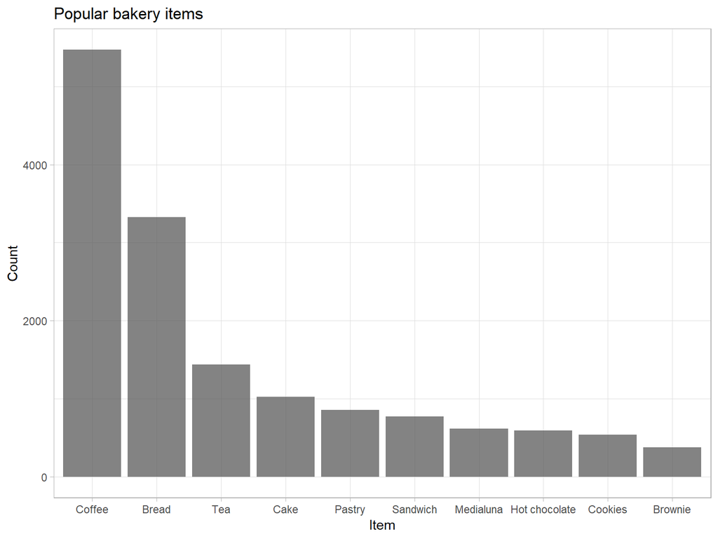

```r
b3 <- dfBakery %>%
  group_by(Item) %>%
  summarise(Count = length(Item)) %>%
  top_n(10) %>%
  ggplot(aes(x=reorder(Item,-Count),y=Count)) +
  theme_light() +
  geom_bar(stat='identity',alpha=0.75) +
  labs(title=paste('Popular bakery items'),
     x = 'Item',
     y = 'Count')
b3
```

The top 10 most popular items that were being bought are Coffee, Bread, Tea, Cake, Pastry, Sandwich, Medialuna, Hot chocolate, Cookies and Brownie.

##### Convert dataframe to transactions data

```r
dfBakery.trans <- read.transactions("C:/Users/gagd2/Desktop/Syracuse/IST_687/Assignments/Project/BreadBasket_DMS.csv",
                       format="single",
                       cols=c(3,4),
                       sep=","
                       )
```

##### Items that are frequently bought together

```r
ruleset <- apriori(dfBakery.trans,parameter=list(support=0.005,confidence=0.5),
   appearance = list(none = c("NONE", "Adjustment"),
   default="both"))
```

```
## Apriori
##
## Parameter specification:
##  confidence minval smax arem  aval originalSupport maxtime support minlen
##         0.5    0.1    1 none FALSE            TRUE       5   0.005      1
##  maxlen target   ext
##      10  rules FALSE
##
## Algorithmic control:
##  filter tree heap memopt load sort verbose
##     0.1 TRUE TRUE  FALSE TRUE    2    TRUE
##
## Absolute minimum support count: 33
##
## set item appearances ...[2 item(s)] done [0.00s].
## set transactions ...[104 item(s), 6614 transaction(s)] done [0.00s].
## sorting and recoding items ... [35 item(s)] done [0.00s].
## creating transaction tree ... done [0.00s].
## checking subsets of size 1 2 3 4 done [0.00s].
## writing ... [17 rule(s)] done [0.00s].
## creating S4 object  ... done [0.00s].
```

```r
inspect(sort(ruleset, by='lift', decreasing = TRUE))
```

```
##      lhs                     rhs      support     confidence lift
## [1]  {Cake,Sandwich}      => {Coffee} 0.005594194 0.7551020  1.566576
## [2]  {Toast}              => {Coffee} 0.025703054 0.7296137  1.513697
## [3]  {Spanish Brunch}     => {Coffee} 0.014061083 0.6326531  1.312537
## [4]  {Cake,Hot chocolate} => {Coffee} 0.006501361 0.6323529  1.311914
## [5]  {Salad}              => {Coffee} 0.007862111 0.6117647  1.269201
## [6]  {Medialuna}          => {Coffee} 0.032960387 0.5751979  1.193337
## [7]  {Sandwich}           => {Coffee} 0.042334442 0.5679513  1.178303
## [8]  {Pastry}             => {Coffee} 0.048684608 0.5590278  1.159790
## [9]  {Alfajores}          => {Coffee} 0.022376777 0.5522388  1.145705
## [10] {Tiffin}             => {Coffee} 0.010583611 0.5468750  1.134577
## [11] {Hearty & Seasonal}  => {Coffee} 0.005443000 0.5454545  1.131630
## [12] {Scone}              => {Coffee} 0.018445721 0.5422222  1.124924
## [13] {Cake}               => {Coffee} 0.056546719 0.5389049  1.118042
## [14] {Juice}              => {Coffee} 0.021318415 0.5300752  1.099723
```

[output cut: 21 more lines]

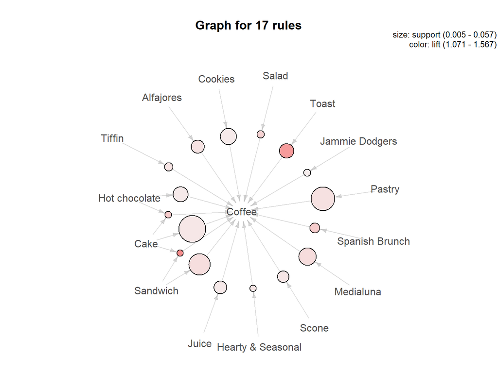

```r
plot(ruleset, method="graph")
```

With a support of 0.005 and confidence of 0.5, 17 rules were generated using the apriori algorithm. The result is displayed in the graph above.

## Weather Data Analysis

#### Load Weather Data

The weather data is divided by month. Since there are seven months of bakery data, seven months of weather data is appended together into a single dataframe.Some data cleaning is necessary as it was found that the timestamp has inconsistent formatting between the months, there are also gaps within the data.

```r
GetWeatherData <- function() {
  nameofColumns <- c('Timestamp','RecordID','Year','Day','Hour','Minute',
                 'BattV_Avg','SWtot_Avg','SWdif_Avg',
                 'Wdir_Avg', 'Wavg_Avg','Wmax_Max',
                 'Tair_Avg','RHum_Avg','Pair_Avg',
                 'Rain','Rintensity_Avg','Hail')

  csvFiles <- c('C:/Users/gagd2/Desktop/Syracuse/IST_687/Assignments/Project/JCMB_2016_Oct.csv','C:/Users/gagd2/Desktop/Syracuse/IST_687/Assignments/Project/JCMB_2016_Nov.csv','C:/Users/gagd2/Desktop/Syracuse/IST_687/Assignments/Project/JCMB_2016_Dec.csv','C:/Users/gagd2/Desktop/Syracuse/IST_687/Assignments/Project/JCMB_2017_Jan.csv','C:/Users/gagd2/Desktop/Syracuse/IST_687/Assignments/Project/JCMB_2017_Feb.csv','C:/Users/gagd2/Desktop/Syracuse/IST_687/Assignments/Project/JCMB_2017_Mar.csv','C:/Users/gagd2/Desktop/Syracuse/IST_687/Assignments/Project/JCMB_2017_Apr.csv')

  df <- NULL

  for (file in csvFiles) {
    data <- read.csv(file,
                     skip = 4,
                     col.names = nameofColumns,
                     stringsAsFactors = FALSE)

    if (grepl('2016',file)) {
      data$Date <- as.Date('2015-12-31') + data$Day
    } else if (grepl('2017', file)) {
      data$Date <- as.Date('2016-12-31') + data$Day
    }

    data <- data[c(19,2,5,6,11,13,14,17)]

    df <- rbind(df,data)
  }

  # filter weather data down to the dates where we have bakery data
  df<- df[df$Date > '2016-10-29' & df$Date <'2017-04-10',]
  df$Rintensity_Avg <- df$Rintensity_Avg/60 # Convert Rintensity from mm/h to mm/min
  df[c(5:8)] <- sapply(df[c(5:8)],as.numeric)

  df$Tair_Avg <- na.approx(df$Tair_Avg,index(df),na.rm = FALSE)

  return(df)
}

dfWeather <- GetWeatherData()

dfWeather.Hour <- dfWeather %>%
    group_by(Date, Hour) %>%
    summarise(Wind=mean(Wavg_Avg),
              MaxTemp=max(Tair_Avg),
              MinTemp=min(Tair_Avg),
              AvgTemp=mean(Tair_Avg),
              Hum=mean(RHum_Avg),
              Rain=sum(Rintensity_Avg))

dfWeather.Day <- dfWeather %>%
    group_by(Date) %>%
    summarise(Wind=mean(Wavg_Avg),
              MaxTemp=max(Tair_Avg),
              MinTemp=min(Tair_Avg),
              AvgTemp=mean(Tair_Avg),
              Hum=mean(RHum_Avg),
              Rain=sum(Rintensity_Avg))
```

Here are the steps that was taken to clean the weather data:

- Remove header rows that are not used
- Recalculate the date
- Remove columns that are not used
- rbind the dataframes into one big dataframe using a loop
- Filter for only the date range with bakery data
- Convert rain intensity from mm/h to mm/min
- Convert numerical columns to numeric format
- Interpolate for missing data

The dataframe is named *dfWeather*, two other dataframes were created to aggregate this data by hour and by day. They are named *dfWeather.Hour* and *dfWeather.Day*, respectively.

## Combine Bakery Data with Weather Data

```r
dfCombined.Day <- merge(dfBakery.Day,dfWeather.Day[c(1,2,5,6,7)],by='Date')
```

The bakery data are combined with weather data by merging on the date column.

#### Heat map of weather versus bakery transactions

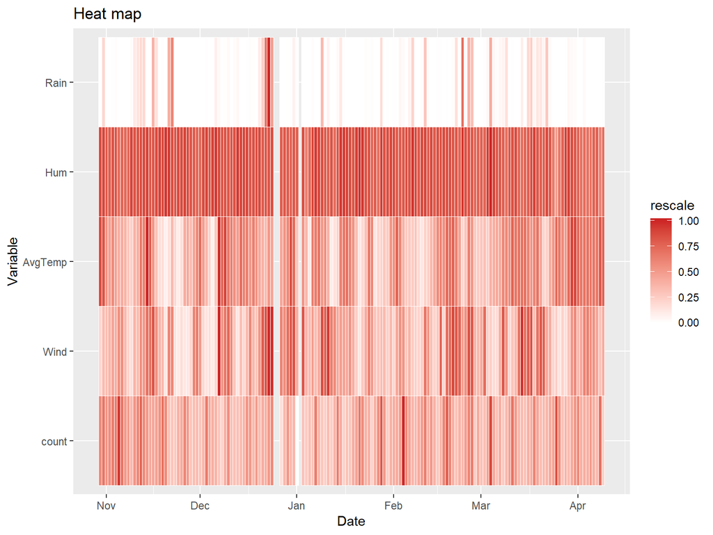

```r
dfCombined.m <- melt(dfCombined.Day,id='Date')
dfCombined.m <- dfCombined.m %>%
  group_by(variable) %>%
  mutate(rescale = value/max(value))

ggplot(dfCombined.m,aes(Date,variable)) +
  geom_tile(aes(fill = rescale), colour = "white")+
  scale_fill_gradient(low = "white", high = "firebrick3") +
  labs(title=paste('Heat map'),
       x = 'Date',
       y = 'Variable')
```

A heat map was created to see the correlation between number of bakery transactions versus the different variables. The trend is inconclusive. Hence, further analysis is done using Time Series plots.

#### Time series plot of weather versus bakery transactions

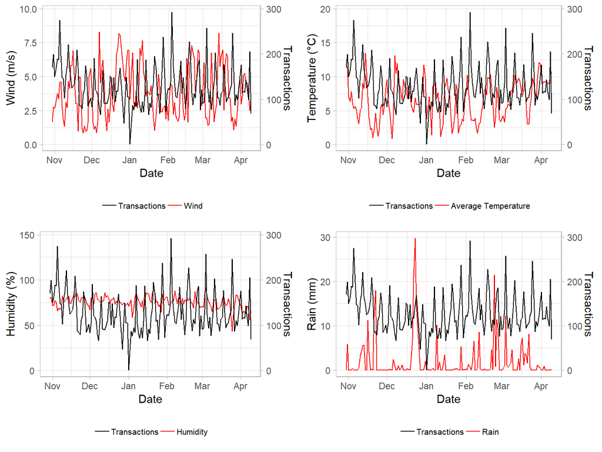

```r
p1 <- ggplot(dfCombined.Day, aes(Date)) +
  geom_line(aes(y = Wind, color = 'Wind')) +
  geom_line(aes(y = count/30, color = 'Transactions')) +
  scale_y_continuous(sec.axis = sec_axis(~.*30, name = 'Transactions')) +
    scale_colour_manual(breaks = c('Transactions','Wind'),
                      values = c('Transactions' = 'black', 'Wind' = 'red')) +
  labs (y = 'Wind (m/s)',
        x = 'Date') +
  theme_light() +
  theme(legend.title = element_blank(),
        legend.position='bottom',
        legend.text = element_text(size = 8))

p2 <- ggplot(dfCombined.Day, aes(Date)) +
  geom_line(aes(y = AvgTemp, colour = 'Average Temperature')) +
  geom_line(aes(y = count/15, colour = 'Transactions')) +
  scale_y_continuous(sec.axis = sec_axis(~.*15, name = 'Transactions')) +
  scale_colour_manual(breaks = c('Transactions','Average Temperature'),
                      values = c('Transactions' = 'black', 'Average Temperature' = 'red')) +
  labs (y = 'Temperature (°C)',
        x = 'Date') +
  theme_light() +
  theme(legend.title = element_blank(),
        legend.position='bottom',
        legend.text = element_text(size = 8))

p3 <- ggplot(dfCombined.Day, aes(Date)) +
  geom_line(aes(y = Hum, colour = 'Humidity')) +
  geom_line(aes(y = count/2, colour = 'Transactions')) +
  scale_y_continuous(sec.axis = sec_axis(~.*2, name = 'Transactions')) +
  scale_colour_manual(breaks = c('Transactions','Humidity'),
                      values = c('Transactions' = 'black', 'Humidity' = 'red')) +
  labs (y = 'Humidity (%)',
        x = 'Date') +
  theme_light() +
  theme(legend.title = element_blank(),
        legend.position='bottom',
        legend.text = element_text(size = 8))

p4 <- ggplot(dfCombined.Day, aes(Date)) +
  geom_line(aes(y = Rain, colour = 'Rain')) +
  geom_line(aes(y = count/10, colour = 'Transactions')) +
  scale_y_continuous(sec.axis = sec_axis(~.*10, name = 'Transactions')) +
  scale_colour_manual(breaks = c('Transactions','Rain'),
                      values = c('Transactions' = 'black', 'Rain' = 'red')) +
  labs (y = 'Rain (mm)',
        x = 'Date') +
  theme_light() +
  theme(legend.title = element_blank(),
        legend.position='bottom',
        legend.text = element_text(size = 8))

grid.arrange(grobs = list(p1,p2,p3,p4))
```

With time series plots, it is pretty clear that the various weather variables are not sigificant inputs in the number of bakery transactions. However, can weather be used to identify what items are being purchased by the customers? Let’s try to get some answers through prediction models.

## Prediction Models

```r
# Reference: https://machinelearningmastery.com/machine-learning-in-r-step-by-step/

dfBakery <- dfBakery[!duplicated(dfBakery),] # Each transaction can only have one of each item (a customer buying 5 coffee, will only be counted as a customer who purchased coffee)

dfBakery.Top10 <- dfBakery[dfBakery$Item %in% c('Coffee', 'Bread', 'Tea', 'Cake', 'Pastry',
                                           'Sandwich', 'Medialuna', 'Hot chocolate', 'Cookies', 'Brownie'),c(1,2,4)]

dfCombined <- merge(dfBakery.Top10,dfWeather.Hour,by=c('Date','Hour'))

TimeOfDay <- cbind(Hour = seq(0,23),
                   TimeOfDay = c(rep(1,6), # 0000 to 0500, early morning
                                 rep(2,6), # 0600 to 1100, morning
                                 rep(3,6), # 1200 to 1700, afternoon
                                 rep(4,6)) # 1800 to 2300, evening
)

dfCombined <- merge(dfCombined,TimeOfDay,by='Hour')
dfCombined$Item <- as.factor(dfCombined$Item)
dfCombined$Weekday <- wday(dfCombined$Date)

dfCombined <- dfCombined[c(10,11,7,8,3)] # SVM and RF take too long, removed some variables

trainIndex <- createDataPartition(dfCombined$Item, p = .7, list = FALSE, times = 1) #70/30 split

trainset <- dfCombined[trainIndex,]
testset <- dfCombined[-trainIndex,]

x <- trainset[,c(1:4)]
y <- trainset$Item

control <- trainControl(method="cv", number=10) # 10-folds cross validation
metric <- "Accuracy"
s <- 2 # Change this before each run

# a) linear algorithms
set.seed(s)
fit.lda <- train(Item~., data=trainset, method="lda", metric=metric, trControl=control)
# b) nonlinear algorithms
# CART
set.seed(s)
fit.cart <- train(Item~., data=trainset, method="rpart", metric=metric, trControl=control)
# kNN
set.seed(s)
fit.knn <- train(Item~., data=trainset, method="knn", metric=metric, trControl=control)
# c) advanced algorithms
# SVM
set.seed(s)
# fit.svm <- train(Item~., data=trainset, method="svmRadial", metric=metric, trControl=control)
# Random Forest
set.seed(s)
fit.rf <- train(Item~., data=trainset, method="rf", metric=metric, trControl=control)


# summarize accuracy of models
# results <- resamples(list(lda=fit.lda, cart=fit.cart, knn=fit.knn, svm=fit.svm,rf=fit.rf))
results <- resamples(list(lda=fit.lda, cart=fit.cart, knn=fit.knn,rf=fit.rf))

summary(results)
```

```
##
## Call:
## summary.resamples(object = results)
##
## Models: lda, cart, knn, rf
## Number of resamples: 10
##
## Accuracy
##           Min.   1st Qu.    Median      Mean   3rd Qu.      Max. NA's
## lda  0.3354701 0.3355598 0.3361839 0.3359711 0.3361884 0.3365385    0
## cart 0.3269231 0.3294968 0.3336902 0.3327639 0.3360985 0.3365385    0
## knn  0.2408994 0.2601496 0.2711273 0.2673285 0.2765160 0.2858672    0
## rf   0.2366167 0.2536733 0.2613568 0.2627222 0.2740899 0.2852564    0
##
## Kappa
##              Min.      1st Qu.       Median          Mean      3rd Qu.
## lda   0.000000000  0.000000000  0.000000000  0.0000000000  0.000000000
## cart -0.005339716 -0.001464723  0.000000000 -0.0007402653  0.000000000
## knn  -0.047580478 -0.020421777 -0.006454164 -0.0112560919  0.002701266
## rf   -0.050552377 -0.031230508 -0.025332295 -0.0252781778 -0.013388772
##              Max. NA's
## lda   0.000000000    0
## cart  0.001648251    0
## knn   0.018666473    0
## rf   -0.008371903    0
```

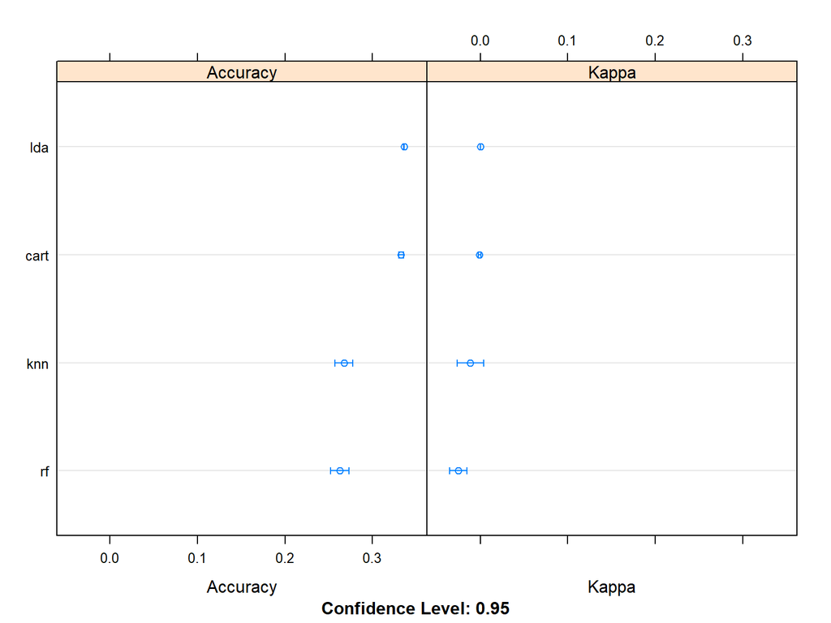

```r
dotplot(results)
```

By taking only the top 10 most popular bakery items into consideration, four prediction models were generated using simple machine learning techniques:

- Linear Discriminant Analysis
- Classification and Regression Trees
- K-Kearest Neighbors
- Random Forests

SVM model was omitted because it took a very long time to run. But, the other four algorithms were able to help draw the conclusion that weather is not the best predictor to predict what is being purchased at a bakery at a given point in time.

#### Linear Discriminant Analysis

```r
predictions <- predict(fit.lda, testset)
confusionMatrix(predictions, testset$Item)
```

```
## Confusion Matrix and Statistics
##
##                Reference
## Prediction      Bread Brownie Cake Coffee Cookies Hot chocolate Medialuna
##   Bread             0       0    0      0       0             0         0
##   Brownie           0       0    0      0       0             0         0
##   Cake              0       0    0      0       0             0         0
##   Coffee          920     111  290   1346     153           163       171
##   Cookies           0       0    0      0       0             0         0
##   Hot chocolate     0       0    0      0       0             0         0
##   Medialuna         0       0    0      0       0             0         0
##   Pastry            0       0    0      0       0             0         0
##   Sandwich          0       0    0      0       0             0         0
##   Tea               0       0    0      0       0             0         0
##                Reference
## Prediction      Pastry Sandwich  Tea
##   Bread              0        0    0
##   Brownie            0        0    0
##   Cake               0        0    0
##   Coffee           242      203  403
##   Cookies            0        0    0
##   Hot chocolate      0        0    0
##   Medialuna          0        0    0
##   Pastry             0        0    0
##   Sandwich           0        0    0
##   Tea                0        0    0
##
## Overall Statistics
##
##                Accuracy : 0.3363
##                  95% CI : (0.3217, 0.3512)
##     No Information Rate : 0.3363
##     P-Value [Acc > NIR] : 0.5059
##
##                   Kappa : 0
##  Mcnemar's Test P-Value : NA
##
## Statistics by Class:
##
##                      Class: Bread Class: Brownie Class: Cake Class: Coffee
```

[output cut: 11 more lines]

```
## Pos Pred Value                  NaN                  NaN              NaN
## Neg Pred Value              0.96177              0.95927          0.95727
## Prevalence                  0.03823              0.04073          0.04273
## Detection Rate              0.00000              0.00000          0.00000
## Detection Prevalence        0.00000              0.00000          0.00000
## Balanced Accuracy           0.50000              0.50000          0.50000
##                      Class: Pastry Class: Sandwich Class: Tea
## Sensitivity                0.00000         0.00000     0.0000
## Specificity                1.00000         1.00000     1.0000
## Pos Pred Value                 NaN             NaN        NaN
## Neg Pred Value             0.93953         0.94928     0.8993
## Prevalence                 0.06047         0.05072     0.1007
## Detection Rate             0.00000         0.00000     0.0000
## Detection Prevalence       0.00000         0.00000     0.0000
## Balanced Accuracy          0.50000         0.50000     0.5000
```

In reviewing the confusion matrix, it was determined that while Linear Discriminant Analysis has the best accuracy, it simply predicts that everyone purchases coffee.

# Conclusion

The goal of this project was to determine the factors that drive the bakery business, develop an understanding of the purchasing behaviors of the customers and determine if weather plays a factor in the bakery transactions.

The last aspect of our analysis was to correlate weather to the purchasing behaviors of customers. While this would have seemed intuitive, no correlation was found between weather conditions and the bakery transactions. One important thing to take into consideration here is the bakery store being located in Edinburgh, UK. Weather is relatively mild and constant in Edinburgh. It rains often and the city doesn’t have a clear demarcation of four seasons. Hence, a study of similar bakery data from a location which experiences more significant weather patterns and seasons may reveal a more significant correlation between weather and purchasing behaviors and give us more valuable insights.